# Logistic regression

### 5) Logistic regression

```r
library(dplyr)

# create log. regr. model with glm()
m <- glm(high_use ~ absences + G3 + freetime + goout, data = stu2, family = "binomial")

# print out a summary of the model
summary(m)
```

```
##
## Call:
## glm(formula = high_use ~ absences + G3 + freetime + goout, family = "binomial",
##     data = stu2)
##
## Deviance Residuals:
##     Min       1Q   Median       3Q      Max
## -1.8991  -0.7493  -0.5454   0.9562   2.3156
##
## Coefficients:
##             Estimate Std. Error z value Pr(>|z|)
## (Intercept) -3.44456    0.74167  -4.644 3.41e-06 ***
## absences     0.07621    0.02232   3.415 0.000639 ***
## G3          -0.04741    0.03895  -1.217 0.223534
## freetime     0.18074    0.13765   1.313 0.189149
## goout        0.66087    0.12345   5.353 8.63e-08 ***
## ---
## Signif. codes:  0 '***' 0.001 '**' 0.01 '*' 0.05 '.' 0.1 ' ' 1
##
## (Dispersion parameter for binomial family taken to be 1)
##
##     Null deviance: 452.04  on 369  degrees of freedom
## Residual deviance: 387.11  on 365  degrees of freedom
## AIC: 397.11
##
## Number of Fisher Scoring iterations: 4
```

**Summary:** According to the fitted model, variables absences and going out have a statistically significant relationship with high use of alcohol. Furthermore, results indicate that the higher value in absences or goout, the more likely it is for a student to be a high user.

Other two variables (freetime and grade) do not have a statistically significant relationship with high_use.

```r
# model coefficients
coef(m)
```

```
## (Intercept)    absences          G3    freetime       goout
## -3.44455619  0.07621284 -0.04740708  0.18074250  0.66086856
```

```r
# compute odds ratios
OR <- coef(m) %>% exp

# compute confidence intervals
CI <- confint(m) %>% exp
# print out the odds ratios with their confidence intervals
cbind(OR, CI)
```

```
##                     OR       2.5 %    97.5 %
## (Intercept) 0.03191892 0.007107958 0.1310842
## absences    1.07919224 1.034335455 1.1301965
## G3          0.95369908 0.883428225 1.0296400
## freetime    1.19810663 0.915713983 1.5731307
## goout       1.93647355 1.529257163 2.4840232
```

Shortly, my hypothesis in the begin was largely accurate. However, I was not that precise with them (I did not consider if some variable will prove statistically significant)

### 6) Cross tabulation with statistically significant variables

```r
library(dplyr)
# Create model with variables with significant relationship with high_use
stu3 <- select(stu2, high_use, absences, goout)
m2 <- glm(high_use ~ absences + goout, data = stu3, family = "binomial")

# predict probability of high use
probabilities <- predict(m2, type="response")

stu3 <- stu3 %>%
  mutate(probability = probabilities) %>%
  mutate(prediction = probability > .5)

# cross tabulation
table(high_use = stu3$high_use, prediction = stu3$prediction)
```

```
##         prediction
## high_use FALSE TRUE
##    FALSE   236   23
##    TRUE     65   46
```

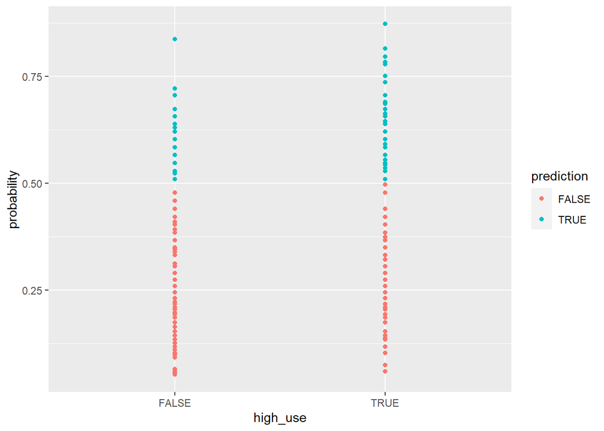

```r
# initialize a plot of 'high_use' versus 'probability' in 'alc'
g <- ggplot(stu3, aes(x = high_use, y = probability))


# define the geom as points and draw the plot
g + geom_point(aes(col=prediction))
```

```r
table(high_use = stu3$high_use, prediction = stu3$prediction) %>% prop.table %>% addmargins
```

```
##         prediction
## high_use      FALSE       TRUE        Sum
##    FALSE 0.63783784 0.06216216 0.70000000
##    TRUE  0.17567568 0.12432432 0.30000000
##    Sum   0.81351351 0.18648649 1.00000000
```

```r
# define a loss function (mean prediction error)
loss_func <- function(class, prob) {
  n_wrong <- abs(class - prob) > 0.5
  mean(n_wrong)
}

loss_func(class = stu3$high_use, prob = stu3$prediction)
```

```
## [1] 0.2378378
```